# 02-quiz-inclass

Charles Reinhardt

“All work presented is my own. I have not communicated with or worked with anyone else on this quiz.”

```r
library(tidyverse)
library(readxl)
#install.packages("here")
library(here)


df <- read_excel(here("data/slu_graduates_17_21.xlsx"))

## fixes error in the data
df <- df %>% mutate(across(everything(),
                           .fns = ~replace(., . ==  "STATS" , "STAT")))

df_long <- df %>% pivot_longer(3:8, names_to = "type", values_to = "discipline")

df_major <- df_long %>%
  filter(type == "major1" | type == "major2" | type == "major3")
```

Question 1 (10 points). Make a lollipop chart of the counts of the top 10 most popular majors at SLU in the past five years, ordering the “lollies” from the most popular major to the 10th most popular major.

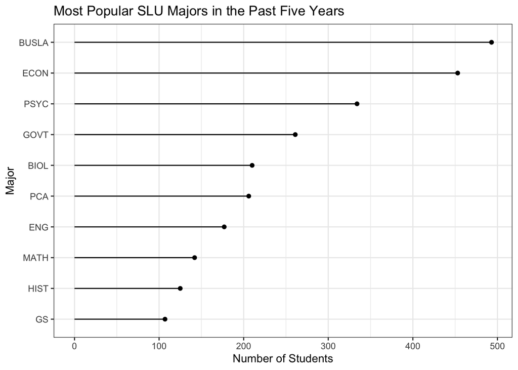

```r
df_major %>%
  filter(!is.na(discipline)) %>%
  group_by(discipline) %>%
  summarise(n_majors = n()) %>%
  mutate(discipline = fct_reorder(discipline, n_majors)) %>%
  slice_max(n_majors, n = 10) %>%

  ggplot(., aes(x = discipline, y = n_majors)) +
  geom_segment(aes(xend=discipline, y=0, yend = n_majors)) +
  geom_point() +
  coord_flip() +
  labs(x = "Major", y = "Number of Students", title = "Most Popular SLU Majors in the Past Five Years") +
  theme_bw()
```

Question 2 (10 points). Make the plot from Question 1 of the take-home quiz, but, instead of plotting the other majors of all of the STAT majors in the data set, plot the counts of the minors of all of the STAT majors.

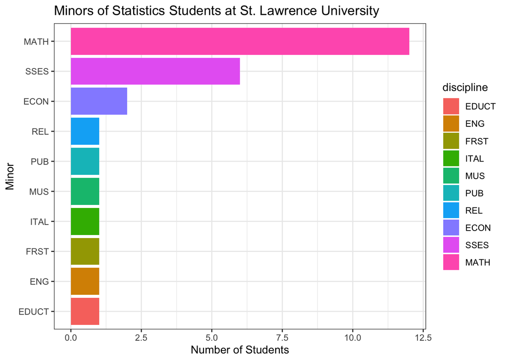

```r
df %>%
  filter(major1 == "STAT" | major2 == "STAT" | major3 == "STAT") %>%
  pivot_longer(c(3, 4, 5, 6, 7,8), values_to = "discipline", names_to = "type") %>%
  filter(type == "minor1" | type == "minor2" | type == "minor3") %>%
  filter(!is.na(discipline)) %>%
  group_by(discipline) %>%
  summarise (nstudent = n()) %>%
  mutate(discipline = fct_reorder(discipline, nstudent)) %>%

  ggplot(., aes(x = discipline, y = nstudent, fill = discipline)) +
  geom_col() +
  coord_flip() +
  labs(y = "Number of Students", x = "Minor", title = "Minors of Statistics Students at St. Lawrence University") +
  theme_bw()
```

Question 3 (5 points). Push your .Rmd and knitted .html file to GitHub, writing a one sentence commit message for your push.

```r
df_major %>%
  filter(!is.na(discipline)) %>%
  summarise(n_students = n_distinct(adm_id), n_majors = n()) %>%
  summarise(average_majors = n_majors / n_students)
```

```
## # A tibble: 1 × 1
##   average_majors
##            <dbl>
## 1           1.35
```